# Importing the libraries and loading the data

```python
import numpy as np # linear algebra
import pandas as pd # data processing, CSV file I/O (e.g. pd.read_csv)
import matplotlib.pyplot as plt

import os
import re
import nltk
from nltk.corpus import stopwords
from sklearn.model_selection import train_test_split
from mlxtend.plotting import plot_confusion_matrix
from sklearn.tree import DecisionTreeClassifier
from sklearn.ensemble import RandomForestClassifier
from sklearn.metrics import accuracy_score,confusion_matrix,classification_report
```

```python
df= pd.read_csv("C:/Users/amitb/Downloads/data/Usecase3_Dataset.csv")
df.head()
```

|  | airline_sentiment | airline | text |
| --- | --- | --- | --- |
| 0 | neutral | Virgin America | @VirginAmerica What @dhepburn said. |
| 1 | positive | Virgin America | @VirginAmerica plus you've added commercials t... |
| 2 | neutral | Virgin America | @VirginAmerica I didn't today... Must mean I n... |
| 3 | negative | Virgin America | @VirginAmerica it's really aggressive to blast... |
| 4 | negative | Virgin America | @VirginAmerica and it's a really big bad thing... |

Data PreprocessingThe first step should be to check the shape of the dataframe and then check the number of null values in each column. In this way we can get an idea of the redundant columns in the data frame depending on which columns have the highest number of null values.

```python
print("Shape of the dataframe is",df.shape)
print("The number of nulls in each column are \n", df.isna().sum())
```

```
Shape of the dataframe is (14640, 3)
The number of nulls in each column are
 airline_sentiment    0
airline              0
text                 0
dtype: int64
```

To get a better idea, lets calculate the percentage of nulls or NA values in each column

```python
print("Percentage null or na values in df")
((df.isnull() | df.isna()).sum() * 100 / df.index.size).round(2)
```

```
Percentage null or na values in df
```

```
airline_sentiment    0.0
airline              0.0
text                 0.0
dtype: float64
```

# Airline sentiments for each airline

Firstly lets calculate the total number of texts for each airline Then, we are going to get the barplots for each airline with respect to sentiments of texts (positive,negative or neutral). This will give us a clearer idea about the airline sentiments , airlines relationship.

```
Total number of texts for each airline
  airline
United            3822
US Airways        2913
American          2759
Southwest         2420
Delta             2222
Virgin America     504
Name: airline_sentiment, dtype: int64
```

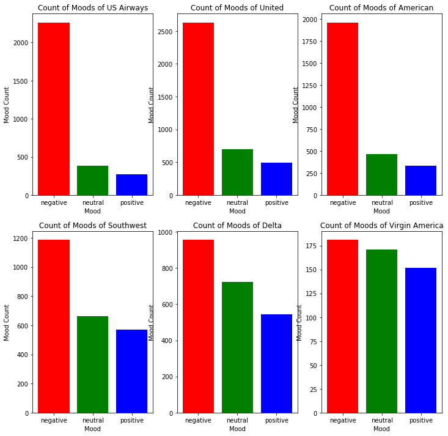

```python
print("Total number of texts for each airline \n ",df.groupby('airline')['airline_sentiment'].count().sort_values(ascending=False))
airlines= ['US Airways','United','American','Southwest','Delta','Virgin America']
plt.figure(1,figsize=(12, 12))
for i in airlines:
    indices= airlines.index(i)
    plt.subplot(2,3,indices+1)
    new_df=df[df['airline']==i]
    count=new_df['airline_sentiment'].value_counts()
    Index = [1,2,3]
    plt.bar(Index,count, color=['red', 'green', 'blue'])
    plt.xticks(Index,['negative','neutral','positive'])
    plt.ylabel('Mood Count')
    plt.xlabel('Mood')
    plt.title('Count of Moods of '+i)
```

1.United, US Airways, American substantially get negative reactions. 2.Texts for Virgin America are the most balanced.

# Most used words in Positive and Negative texts

1.The goal is to firstly get an idea of the most frequent words in negative texts. 2.Get idea about most frequent words in positive texts.

# Wordcloud for Negative sentiments of texts

Wordcloud is a great tool for visualizing nlp data. The larger the words in the wordcloud image , the more is the frequency of that word in our text data.

```python
from wordcloud import WordCloud,STOPWORDS
```

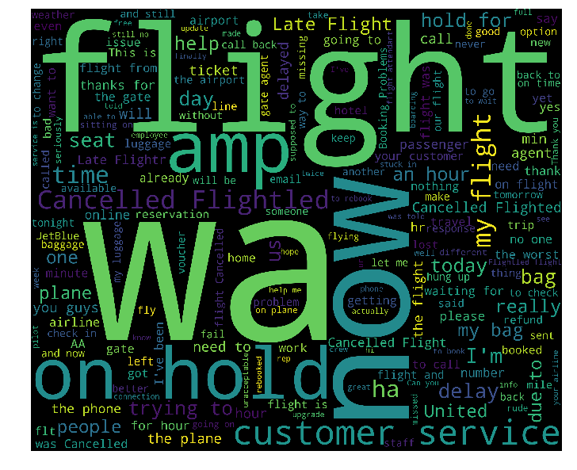

```python
new_df=df[df['airline_sentiment']=='negative']
words = ' '.join(new_df['text'])
cleaned_word = " ".join([word for word in words.split()
                            if 'http' not in word
                                and not word.startswith('@')
                                and word != 'RT'
                            ])
wordcloud = WordCloud(stopwords=STOPWORDS,
                      background_color='black',
                      width=3000,
                      height=2500
                     ).generate(cleaned_word)
plt.figure(1,figsize=(12, 12))
plt.imshow(wordcloud)
plt.axis('off')
plt.show()
```

# Wordcloud for positive reasons

The code for getting positive sentiments is completely same with the one for negative sentiments. Just replace negative with positive in the first line. Easy, right!

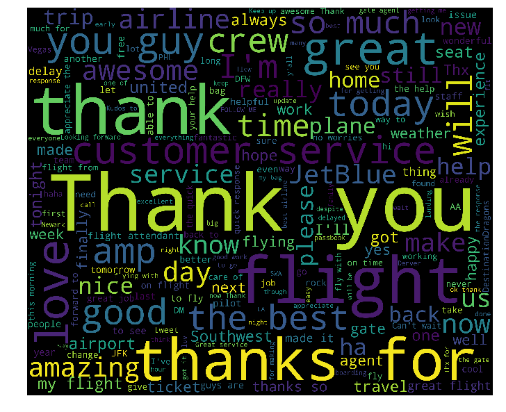

```python
new_df=df[df['airline_sentiment']=='positive']
words = ' '.join(new_df['text'])
cleaned_word = " ".join([word for word in words.split()
                            if 'http' not in word
                                and not word.startswith('@')
                                and word != 'RT'
                            ])
wordcloud = WordCloud(stopwords=STOPWORDS,
                      background_color='black',
                      width=3000,
                      height=2500
                     ).generate(cleaned_word)
plt.figure(1,figsize=(12, 12))
plt.imshow(wordcloud)
plt.axis('off')
plt.show()
```

# Lets try and calculate the highest frequency words in postive sentimental texts

```python
# Calculate highest frequency words in positive texts
def freq(str):

    # break the string into list of words
    str = str.split()
    str2 = []

    # loop till string values present in list str
    for i in str:

        # checking for the duplicacy
        if i not in str2:

            # insert value in str2
            str2.append(i)

    for i in range(0, len(str2)):
        if(str.count(str2[i])>50):
            print('Frequency of', str2[i], 'is :', str.count(str2[i]))

print(freq(cleaned_word))
```

```
Frequency of to is : 923
Frequency of the is : 924
Frequency of time is : 59
Frequency of I is : 574
Frequency of fly is : 54
Frequency of this is : 143
Frequency of :) is : 96
Frequency of it is : 166
Frequency of was is : 226
Frequency of and is : 416
Frequency of an is : 74
Frequency of good is : 75
Frequency of so is : 163
Frequency of much is : 54
Frequency of is is : 219
Frequency of a is : 501
Frequency of great is : 144
Frequency of my is : 320
Frequency of &amp; is : 77
Frequency of on is : 327
Frequency of I'm is : 67
Frequency of flying is : 59
Frequency of your is : 212
Frequency of all is : 92
Frequency of from is : 124
Frequency of Thanks! is : 69
Frequency of for is : 658
Frequency of flight is : 263
Frequency of but is : 91
Frequency of you is : 509
Frequency of would is : 56
Frequency of be is : 135
Frequency of with is : 195
Frequency of you. is : 77
Frequency of love is : 85
Frequency of You is : 62
Frequency of are is : 120
Frequency of of is : 236
Frequency of that is : 102
Frequency of in is : 309
```

[output cut: 17 more lines]

```
Frequency of thanks is : 218
Frequency of get is : 111
Frequency of me is : 196
Frequency of service is : 100
Frequency of you! is : 129
Frequency of Thanks is : 177
Frequency of as is : 57
Frequency of thank is : 204
Frequency of will is : 85
Frequency of our is : 64
Frequency of up is : 66
Frequency of guys is : 76
Frequency of got is : 85
Frequency of made is : 55
None
```

1. Words like Thanks, best, customer , love, flying , good are understandably present in the most frequent words of positive texts. 2. However, other than these, most of the words are stop words and need to be filtered. We will do so later.

# Preprocessing the text data

```python
def text_to_words(df):
    letters_only = re.sub("[^a-zA-Z]", " ",df)
    words = letters_only.lower().split()
    stops = set(stopwords.words("english"))
    meaningful_words = [w for w in words if not w in stops]
    return( " ".join( meaningful_words ))
```

```python
df['clean_text']=df['text'].apply(lambda x: text_to_words(x))
```

The data is split in the standard 80,20 ratio.

```python
train,test = train_test_split(df,test_size=0.2,random_state=42)
```

```python
train_clean_text=[]
for df in train['clean_text']:
    train_clean_text.append(df)
test_clean_text=[]
for df in test['clean_text']:
    test_clean_text.append(df)
```

```python
from sklearn.feature_extraction.text import CountVectorizer
v = CountVectorizer(analyzer = "word")
train_features= v.fit_transform(train_clean_text)
test_features=v.transform(test_clean_text)
```

# Prediciting sentiments from text data

1. Decision Tree Classifier 2. Random Forest Classifier

```python
Classifiers = [
    DecisionTreeClassifier(),
    RandomForestClassifier(n_estimators=200)]
```

```
Accuracy of DecisionTreeClassifieris 0.6915983606557377
              precision    recall  f1-score   support

    negative       0.79      0.81      0.80      1854
     neutral       0.46      0.42      0.44       647
    positive       0.57      0.61      0.59       427

    accuracy                           0.69      2928
   macro avg       0.61      0.61      0.61      2928
weighted avg       0.69      0.69      0.69      2928
```

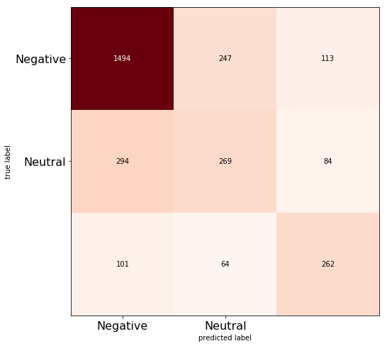

```
Accuracy of RandomForestClassifieris 0.7739071038251366
              precision    recall  f1-score   support

    negative       0.91      0.82      0.86      2093
     neutral       0.46      0.59      0.52       456
    positive       0.61      0.74      0.67       379

    accuracy                           0.77      2928
   macro avg       0.66      0.72      0.68      2928
weighted avg       0.80      0.77      0.78      2928
```

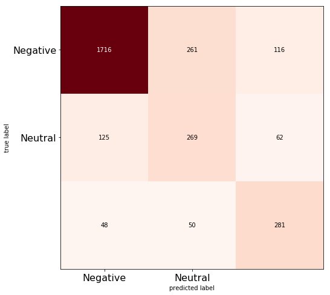

```python
dense_features=train_features.toarray()
dense_test= test_features.toarray()
Accuracy=[]
Model=[]
for classifier in Classifiers:
    try:
        fit = classifier.fit(train_features,train['airline_sentiment'])
        pred = fit.predict(test_features)
    except Exception:
        fit = classifier.fit(dense_features,train['airline_sentiment'])
        pred = fit.predict(dense_test)
    accuracy = accuracy_score(pred,test['airline_sentiment'])
    Accuracy.append(accuracy)
    Model.append(classifier.__class__.__name__)
    print('Accuracy of '+classifier.__class__.__name__+'is '+str(accuracy))
    print(classification_report(pred,test['airline_sentiment']))
    cm=confusion_matrix(pred , test['airline_sentiment'])
    plt.figure()
    plot_confusion_matrix(cm,figsize=(12,8), hide_ticks=True,cmap=plt.cm.Reds)
    plt.xticks(range(2), ['Negative', 'Neutral', 'Positive'], fontsize=16,color='black')
    plt.yticks(range(2), ['Negative', 'Neutral', 'Positive'], fontsize=16)
    plt.show()
```

As we you can see above we have plotted the confusion matrix for predicted sentiments and actual sentiments (negative,neutral and positive)Random Forest Classifier gives us the best accuracy score, precision scores according to the classification report.The confusion matrix shows the TP,TN,FP,FN for all the 3 sentiments(negative,neutral and positive),Here also Random Forest Classifier gives better results than the Decision Tree Classifier.